# 04_Numerical_Analysis_textbook

## 6.3. The Implicit Method

Chapter 4 had a cure for exactly this disease: evaluate the right-hand side at the **new** time level, which is backward Euler. Applied to the heat equation it gives the **BTCS** (backward time, central space) scheme,

$$ \frac{u_i^{n+1} - u_i^n}{\Delta t} = \alpha\left(\frac{u_{i+1}^{n+1} - 2u_i^{n+1} + u_{i-1}^{n+1}}{\Delta x^2}\right) , $$

or, after multiplying by $\Delta t$ and collecting the unknown new values on the left,

$$ -r\,u_{i-1}^{n+1} + (1 + 2r)\,u_i^{n+1} - r\,u_{i+1}^{n+1} = u_i^n , \qquad r = \frac{\alpha\,\Delta t}{\Delta x^2} . $$

Compare this with the explicit update of Section 6.2.1. There, the left-hand side contained one unknown and the right-hand side only known values. Here, **three** unknowns of the new level appear in every equation. Writing the equation out for $i = 1, 2, 3, \dots$ at a fixed time level $n$ shows the consequence:

$$ \begin{aligned} i = 1: \quad & -r\,u_0^{n+1} + (1+2r)\,u_1^{n+1} - r\,u_2^{n+1} = u_1^n, \\ i = 2: \quad & -r\,u_1^{n+1} + (1+2r)\,u_2^{n+1} - r\,u_3^{n+1} = u_2^n, \\ i = 3: \quad & -r\,u_2^{n+1} + (1+2r)\,u_3^{n+1} - r\,u_4^{n+1} = u_3^n, \\ & \;\;\vdots \\ i = N_x - 1: \quad & -r\,u_{N_x-2}^{n+1} + (1+2r)\,u_{N_x-1}^{n+1} - r\,u_{N_x}^{n+1} = u_{N_x-1}^n . \end{aligned} $$

The unknown $u_2^{n+1}$ appears in the first line, the second and the third; $u_3^{n+1}$ in the second, third and fourth; and so on. No line can be evaluated on its own, because each contains two unknowns that are only determined by its neighbours. The new values are **coupled** to each other, and the list of lines is not a loop but a **linear system** in the $N_x - 1$ unknowns $u_1^{n+1}, \dots, u_{N_x-1}^{n+1}$. This is the difference between explicit and implicit in one sentence: in the explicit scheme every line has one unknown and the inner loop just evaluates it; in the implicit scheme every line has three, and the inner loop is replaced by a solve.

Two of the lines contain a value that is *not* an unknown. The first contains $u_0^{n+1}$ and the last contains $u_{N_x}^{n+1}$, which are the boundary values at the new time level, given by the boundary conditions. As in Chapter 5, a known quantity is moved to the right-hand side, and the first and last lines become

$$ \begin{aligned} i = 1: \quad & (1+2r)\,u_1^{n+1} - r\,u_2^{n+1} = u_1^n + r\,u_0^{n+1}, \\ i = N_x - 1: \quad & -r\,u_{N_x-2}^{n+1} + (1+2r)\,u_{N_x-1}^{n+1} = u_{N_x-1}^n + r\,u_{N_x}^{n+1} . \end{aligned} $$

Now each line becomes one row of a matrix, with the coefficient of $u_j^{n+1}$ in column $j$: the entry $1+2r$ on the diagonal, and $-r$ on either side of it, except in the first and last rows where one of the $-r$'s has moved to the right with its boundary value. Each step therefore requires **solving a linear system** $A u^{n+1} = b$ ,

$$ \underbrace{ \begin{bmatrix} 1+2r & -r & & \\ -r & 1+2r & -r & \\ & \ddots & \ddots & \ddots \\ & & -r & 1+2r \end{bmatrix} }_{A} \underbrace{ \begin{bmatrix} u_1^{n+1} \\ u_2^{n+1} \\ \vdots \\ u_{N_x-1}^{n+1} \end{bmatrix} }_{u^{n+1}} = \underbrace{ \begin{bmatrix} u_1^n + r\,u_0^{n+1} \\ u_2^n \\ \vdots \\ u_{N_x-1}^n + r\,u_{N_x}^{n+1} \end{bmatrix} }_{b} . $$

This is precisely the kind of system built in Chapter 5 — tridiagonal, one row per interior point, with the boundary values entering the right-hand side. The matrix $A$ contains only $r$ and does not change from step to step, so it is assembled once; the right-hand side is rebuilt at every step from the current level and the boundary values, and one linear solve returns the whole new level. The inner loop of the explicit method has become a solve; the march in time is unchanged.

The amplification factor of this scheme is $g_j = 1/\bigl(1 + 4r\sin^2(j\pi\Delta x/2)\bigr)$, which is smaller than one in magnitude for **every** $r$ and every mode. The implicit method is **unconditionally stable**: the time step may be chosen for accuracy alone.

```python
r = 2.5                                 # five times the explicit limit
dt = r*dx**2/alpha
Nt = int(round(T/dt))

print('r = %.1f    dt = %.2e    number of time steps = %d' % (r, dt, Nt))

# the same tridiagonal assembly as in Chapter 5
A = np.zeros((Nx - 1, Nx - 1))

for i in range(Nx - 1):
    A[i, i] = 1 + 2*r
    if i > 0:
        A[i, i - 1] = -r
    if i < Nx - 2:
        A[i, i + 1] = -r
```

```
r = 2.5    dt = 1.00e-03    number of time steps = 100
```

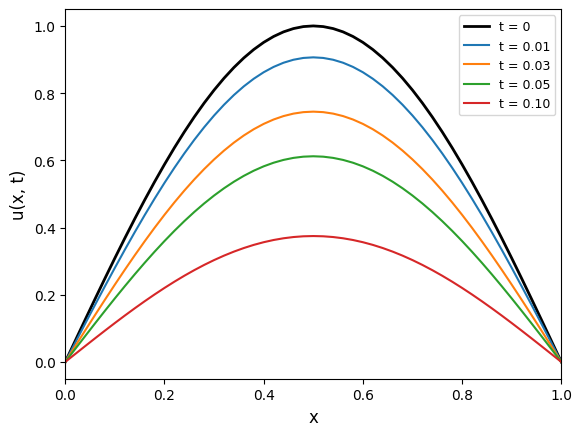

```
max error at t = 0.10   1.93e-03
```

```python
u = np.sin(np.pi*x/L)
u[0] = 0
u[-1] = 0

plt.plot(x, u, 'k', linewidth = 2)

t = 0
for n in range(Nt):
    b = u[1:-1].copy()
    b[0] = b[0] + r*u[0]                # the two boundary values
    b[-1] = b[-1] + r*u[-1]

    u[1:-1] = np.linalg.solve(A, b)     # one linear solve per time step
    t = t + dt

    for tp in [0.01, 0.03, 0.05, 0.10]:
        if abs(t - tp) < dt/2:
            plt.plot(x, u, linewidth = 1.5)

plt.xlim([0, 1])
plt.xlabel('x', fontsize = 12)
plt.ylabel('u(x, t)', fontsize = 12)
plt.legend(['t = 0', 't = 0.01', 't = 0.03', 't = 0.05', 't = 0.10'], fontsize = 9, loc = 'upper right')
plt.show()

print('max error at t = %.2f   %8.2e' % (t, np.max(np.abs(u - uexact(x, t)))))
```

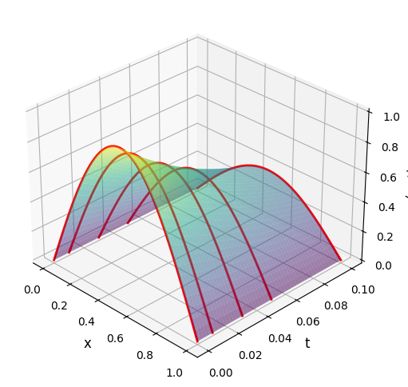

```python
# the whole history in one array: one row per time level, one column per grid point

U = np.zeros((Nt + 1, Nx + 1))
U[0, :] = np.sin(np.pi*x/L)             # initial temperature (both ends already zero)

for n in range(Nt):
    b = U[n, 1:-1].copy()               # right-hand side from the current level
    b[0] = b[0] + r*U[n+1, 0]           # the two boundary values at the new level
    b[-1] = b[-1] + r*U[n+1, -1]
    U[n+1, 1:-1] = np.linalg.solve(A, b)        # one linear solve per time step

tgrid = np.arange(Nt + 1)*dt
X, Tg = np.meshgrid(x, tgrid)           # X[n, i] = x_i,  Tg[n, i] = t_n,  U[n, i] = u(x_i, t_n)

plt.figure(figsize = (9, 6))
ax = plt.axes(projection = '3d')
ax.plot_surface(X, Tg, U, cmap = 'viridis', rstride = 2, cstride = 1, linewidth = 0, alpha = 0.5)
for tp in [0, 0.01, 0.03, 0.05, 0.10]:
    n = int(round(tp/dt))               # time level closest to tp
    ax.plot(x, tp*np.ones(Nx + 1), U[n, :], linewidth = 2, color = 'r')
ax.set_xlabel('x', fontsize = 12)
ax.set_ylabel('t', fontsize = 12)
ax.set_zlabel('u(x, t)', fontsize = 12)
ax.view_init(elev = 30, azim = -45)
plt.show()
```

With $r = 2.5$, five times the explicit limit, the solution is perfectly well behaved: one hundred steps instead of five hundred and fifty-six, and no sign of a sawtooth. The price is accuracy rather than stability — the error is $1.9 \times 10^{-3}$ against $2.1 \times 10^{-4}$, because backward Euler is only first order in time and the step is five and a half times longer.

|  | explicit (FTCS) | implicit (BTCS) |
| --- | --- | --- |
| time derivative | forward difference | backward difference |
| space derivative evaluated at | $t_n$ | $t_{n+1}$ |
| work per step | one algebraic update | one linear solve $Au = b$ |
| stability | conditional, $r \le 1/2$ | unconditional, any $r > 0$ |
| cost | cheap per step, many steps | dearer per step, few steps |

That trade is what decides which method is used. If the accuracy wanted in time is comparable to the stability limit anyway, the explicit method is simpler and cheaper. If the stability limit is far below what accuracy requires — the usual situation on a fine grid — the implicit method wins, and the cost of a tridiagonal solve per step is repaid many times over.

> **Remark (other boundary conditions).** An insulated end, $\partial u/\partial x = 0$ at $x = L$, is the Neumann condition of Section 5.2.3 and is handled in the same way: $u_{N_x}$ becomes an unknown, the system gains one row, and that row is a discretization of the boundary condition rather than of the PDE. The crude version $u_{N_x}^{n+1} = u_{N_x-1}^{n+1}$ is first-order accurate and costs an order at that end; the three-point one-sided formula preserves second order.

> **Remark (two space dimensions).** On a rectangle, $u_{xx} + u_{yy}$ is discretized by applying the same three-point stencil in each direction, giving the **five-point stencil** $(u_{i-1,j} + u_{i+1,j} + u_{i,j-1} + u_{i,j+1} - 4u_{ij})/\Delta x^2$. Everything above carries over: the explicit method is still one line, its stability limit tightens to $r \le 1/4$, and the implicit method still requires a linear solve. What changes is the matrix. With $N$ points in each direction there are $N^2$ unknowns, and the matrix is no longer tridiagonal but sparse with five nonzero diagonals. Storing it as a full array, as was done here for clarity, becomes impossible almost immediately, and solving it efficiently — by sparse factorization or by iterative methods — is the subject on which large-scale scientific computing rests.

This chapter completes the pattern of the whole notebook. A derivative was replaced by a difference of neighbouring values in Chapter 2; that difference became a time-stepping rule in Chapter 4 and a matrix in Chapter 5; here it is both at once, and the balance between them — how far one may step in time given how finely one has divided space — is the central question of numerical simulation.

# Summary

**Key takeaways**

**Roots of nonlinear equations**

- Roots of nonlinear equations are found iteratively. What a program can measure is the residual $f(\tilde r)$, a backward error: a small residual means that an exactly solvable nearby problem has been solved.
- Bisection needs only a sign change, $f(a) f(b) < 0$, and continuity. It cannot fail, and its error obeys the a-priori bound $|x_k - r| \le (b-a)/2^k$ — linear convergence with rate $1/2$, about one decimal digit per three evaluations.
- Fixed-point iteration $x_{k+1} = g(x_k)$ converges linearly with rate $|g'(p)|$ when this is less than $1$, and diverges otherwise; the rate is decided by how the equation was rearranged.
- Newton's method solves the tangent-line model at every step, $x_{k+1} = x_k - f(x_k)/f'(x_k)$. Because the rearrangement makes $g'(r) = 0$, the convergence to a simple root is quadratic and the number of correct digits roughly doubles per iteration — but only from a start close enough to the root.
- The secant method replaces $f'$ by a difference quotient through the last two iterates, costs one function evaluation per step, and converges with order $(1 + \sqrt 5)/2 \approx 1.618$, which usually makes it the cheapest of the three per digit gained.
- Guarantee and speed pull in opposite directions: bisection has the first and not the second, Newton the second and not the first. Practical software keeps a bracket and takes fast steps inside it.

**Finite difference derivatives**

- A finite difference is the definition of the derivative with the limit stopped short. One pair of Taylor expansions, one step to the right and one to the left, produces every formula of Chapter 2 and, at the same time, its error.
- Forward and backward differences are first-order accurate, with leading errors $\pm\tfrac{\Delta x}{2}f''$ — equal in size, opposite in sign. Plotted over an interval they appear shifted half a step to the left and to the right of the exact derivative.
- The central difference averages the two, cancels that term, and is second-order accurate at the same cost of two function evaluations. Symmetry is what buys the accuracy: a symmetric stencil cannot contain an odd power of $\Delta x$ in its error.
- Adding rather than subtracting the two expansions gives $f'' \approx (f_{k+1} - 2f_k + f_{k-1})/\Delta x^2$, the discrete Laplacian, also second-order accurate. Any order can be reached by using more points and choosing the coefficients so that the low-order error terms cancel.
- An order of accuracy is a slope on a log-log plot of error against $\Delta x$, and checking that slope is the standard test of a discretization.
- On a grid, use the central difference on the interior points and one-sided formulas at the two ends. A first-order end formula costs an order of accuracy there; a second-order one, built from three points, restores it.

**Numerical integration**

- Numerical integration replaces $\int_a^b f\,dx$ by a weighted sum of samples, $\sum_k w_k f(x_k)$. The methods differ only in the weights.
- The definition of the integral is itself the first method: with $\Delta x = (b-a)/N$ and $x_k = a + k\Delta x$, dropping the limit from the Riemann sum gives the left-sided rule $\Delta x\sum_{k=0}^{N-1} f_k$ and the right-sided rule $\Delta x\sum_{k=1}^{N} f_k$.
- Both rectangle rules are first-order accurate, with errors $\mp\tfrac{\Delta x}{2}(f(b) - f(a))$ — equal in size and opposite in sign. They differ from each other by exactly $(f(b) - f(a))\Delta x$.
- Averaging them cancels that term and gives the trapezoidal rule, $\tfrac{\Delta x}{2}\sum(f_k + f_{k+1})$, equivalently $\Delta x(\tfrac{f_0}{2} + f_1 + \cdots + f_{N-1} + \tfrac{f_N}{2})$. It is second-order accurate at no extra cost, with error $-\tfrac{\Delta x^2}{12}(f'(b) - f'(a))$ — and spectrally accurate for a smooth periodic integrand over a whole number of periods.
- **Monte Carlo integration** replaces the grid by random samples: with $x_j$ drawn uniformly from $\Omega$, the integral is the expected value $|\Omega|\,\mathbb{E}[f(X)]$ and is estimated by the sample mean $\frac{|\Omega|}{N}\sum_j f(x_j)$. The hit-or-miss variant does the same for an area, counting the fraction of points that land inside the region.
- Its error decays only as $O(N^{-1/2})$, far more slowly than a grid rule in one dimension, but that exponent is **independent of dimension**. A grid rule in $d$ dimensions has spacing $N^{-1/d}$, so the trapezoidal error becomes $O(N^{-2/d})$; the two rates cross at $d = 4$, and beyond it the grid rule loses badly. This is the curse of dimensionality, and escaping it is why sampling is used.

**Numerical solutions to ODEs**

- Any differential equation is put in the form $\dot{x} = f(x)$, $x(0) = x_0$, by adding derivatives as extra states. A numerical solver returns not a function but a **trajectory**: a list of states $x_0 \to x_1 \to \cdots \to x_N$ at the times $t_k = k\Delta t$.
- **Forward Euler**, $x_{k+1} = x_k + \Delta t f(x_k)$, evaluates the slope at the known point and is explicit. **Backward Euler**, $x_{k+1} = x_k + \Delta t f(x_{k+1})$, evaluates it at the unknown point and requires solving an equation each step. For a linear system they become $(I + \Delta t A)x_k$ and $(I - \Delta t A)^{-1}x_k$.
- The **local error** of one Euler step is $O(\Delta t^2)$, but $N \propto 1/\Delta t$ steps are needed, so the **global error** is $O(\Delta t)$: both methods are first order, and the measured error ratio under step halving is $2$. Forward and backward Euler are the rectangle rules of Chapter 3 in disguise, and averaging them gives the second-order Crank-Nicolson method.
- **Stability** is a separate question from accuracy. On $\dot y = \lambda y$ each step multiplies by a fixed factor, so with $z = \lambda\Delta t$ forward Euler is stable only for $|1 + z| \le 1$ — a disc of radius one centred at $-1$ — while backward Euler is stable for $|1 - z| \ge 1$, which includes the whole left half-plane.
- For a system, the same test reads $|\text{eig}(I + \Delta t A)| \le 1$. With real negative eigenvalues this caps the step at $\Delta t \le 2/|\lambda|_{\max}$, set by the **fastest** mode even when that mode has long since decayed. Systems with widely separated eigenvalues are **stiff**, and implicit methods exist to handle them.
- The same loop works unchanged for nonlinear $f$. On an undamped oscillator, whose eigenvalues are purely imaginary, forward Euler is unstable for every step size and steadily injects energy — a failure of the method, not of the step size.

**Boundary value problems**

- A boundary value problem gives conditions at the two ends of the interval, so there is no complete state to march forward from and the unknowns are all coupled. Replacing $u''$ by the three-point central stencil at every interior point turns $u'' = f$ into a linear system $Au = b$ with one equation per unknown.
- The matrix is the discrete Laplacian $(1, -2, 1)/\Delta x^2$ and is **tridiagonal**, because the stencil couples each point only to its neighbours. The known boundary values never enter the matrix; they move to the first and last entries of the right-hand side.
- The scheme inherits the order of its stencil: the error falls by a factor of $4$ each time the grid is halved. A Neumann condition adds one row, and a first-order boundary formula there would cost that second order.
- A time-stepping method applies the stencil sequentially; a boundary value method assembles it into a matrix and solves once.

**Partial differential equations**

- A PDE has several independent variables. Second-order equations are hyperbolic (waves), parabolic (diffusion) or elliptic (equilibrium) according to the sign of $B^2 - 4AC$; Chapter 5 was the elliptic case in one dimension, and the heat equation $u_t = \alpha u_{xx}$ is the parabolic model problem.
- Discretizing both variables gives $u_i^n$ on a grid in space and time. A forward difference in time and the central stencil in space give the **explicit** scheme $u_i^{n+1} = u_i^n + r(u_{i+1}^n - 2u_i^n + u_{i-1}^n)$ with mesh ratio $r = \alpha\Delta t/\Delta x^2$ — one line, no system to solve.
- The explicit scheme is stable only for $r \le 1/2$. Beyond that the centre weight $1 - 2r$ turns negative, the shortest grid mode is amplified by $|1 - 4r| > 1$, and the solution fills with a sawtooth — which grows from roundoff and so may stay invisible for hundreds of steps. Because the limit involves $\Delta x^2$, refining the grid by two multiplies the work by eight.
- Evaluating the space derivative at the new time level gives the **implicit** scheme, which requires solving a tridiagonal system — the one assembled in Chapter 5 — at every step, and is unconditionally stable. The choice between the two is cheap steps under a stability limit against dearer steps without one.

**Looking ahead.** One idea runs through all six chapters: replace the problem you cannot solve by a local model you can — a tangent or secant line for a root, a truncated Taylor series for a derivative, a constant or a straight line for an integral, one step of an integral for a differential equation. Each of the topics continues from where it stops here. For nonlinear equations the derivative becomes the Jacobian matrix and each Newton step is a linear system, and the same trade-off between a fast step and a safe one reappears in optimization. The finite difference method of Chapters 5 and 6 continues into two and three space dimensions, where the same stencil gives a large sparse matrix rather than a tridiagonal one, and solving it efficiently — rather than by the general-purpose elimination used here — is what makes large-scale simulation possible. Quadrature continues by interpolating at more points and integrating the interpolant, which is how the higher-order rules in reference books are generated. In the other direction it continues by sampling: the $O(N^{-1/2})$ rate that is indifferent to dimension is what makes expected values over high-dimensional distributions computable at all, and it underlies the stochastic estimates of gradients and losses on which machine learning rests. And for initial value problems, evaluating $f$ at several points inside a step buys much higher order for modest extra cost — the Runge-Kutta family, whose fourth-order member is the engine inside `solve_ivp`'s default `RK45`, with adaptive step size control on top.